# Coronavirus_exercicio

### **3- Análise dos 5 paises com mais casos, onde iremos explorar as 3 possíveis situações (Confirmado, Recuperado e óbito)**

- Descobrindo o **Top 5** dos países com mais casos **confirmados**

```r
total_mundo_5 <- coronavirus %>%
  filter(type=='confirmed') %>%
  group_by(country) %>%
  summarise(total_casos = sum(cases))%>%
  arrange(-total_casos)
total_mundo_5[1:5,1]
```

```
## # A tibble: 5 x 1
##   country
##   <chr>
## 1 US
## 2 India
## 3 Brazil
## 4 France
## 5 Russia
```

- Temos o país, as 3 possíveis situações: **confirmado, recuperado e óbito** e o total de casos.

```r
total_3situacoes_5 <- coronavirus %>%
  filter(country %in% c('US','India','Brazil','France','Russia')) %>%
  group_by(country, type) %>%
  summarise(total_casos = sum(cases))%>%
  arrange(country)
total_3situacoes_5
```

```
## # A tibble: 15 x 3
## # Groups:   country [5]
##    country type      total_casos
##    <chr>   <chr>           <int>
##  1 Brazil  confirmed     6071401
##  2 Brazil  death          169183
##  3 Brazil  recovered     5457973
##  4 France  confirmed     2191180
##  5 France  death           48807
##  6 France  recovered      157259
##  7 India   confirmed     9139865
##  8 India   death          133738
##  9 India   recovered     8562641
## 10 Russia  confirmed     2071858
## 11 Russia  death           35838
## 12 Russia  recovered     1582768
## 13 US      confirmed    12246849
## 14 US      death          256782
## 15 US      recovered     4526513
```

#### **A proporção de recuperação, mortes e confirmações de COVID**

- Explorando em um gráfico de barras as 3 situações por país

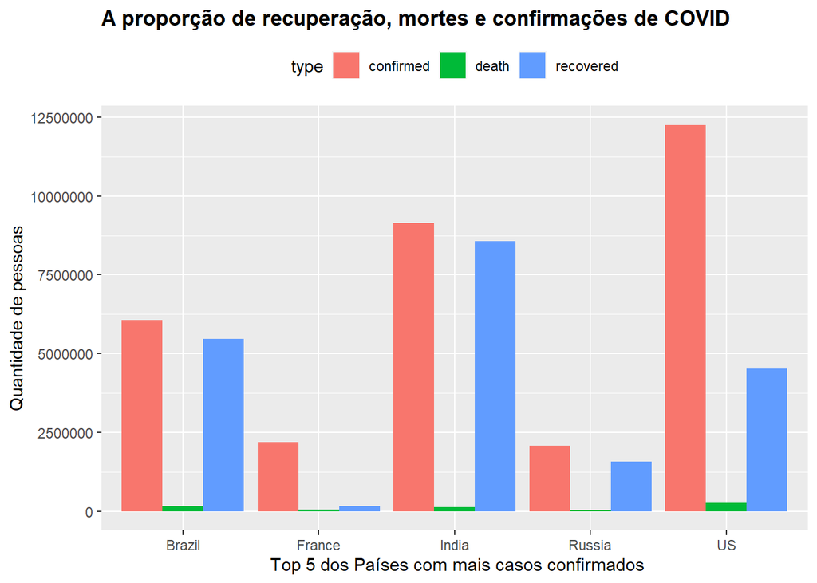

```r
g1 <- ggplot(total_3situacoes_5, aes(y = total_casos, x = country, fill = type)) +
  geom_bar(stat = "identity", position='dodge')+
  labs(title = expression (paste(bold('A proporção de recuperação, mortes e confirmações de COVID'))),
  y = 'Quantidade de pessoas',
  x = ' Top 5 dos Países com mais casos confirmados')+
  theme(legend.position = "top")

g1
```

#### **Total de casos de óbito por COVID**

- Observando apenas os casos de óbito em um gráfico de barras do top 5 de casos confirmados.

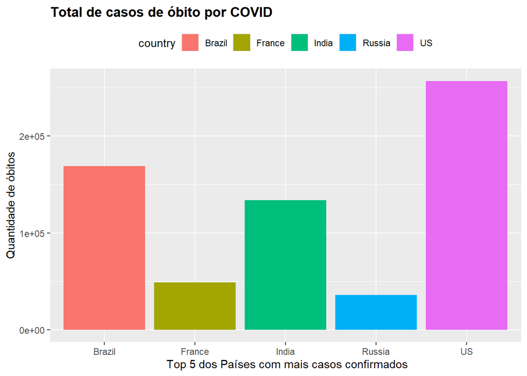

```r
total_3situacoes_5_obito<-  filter(total_3situacoes_5, type == "death")

#total_3situacoes_5_obito

g1 <- ggplot(total_3situacoes_5_obito, aes(y = total_casos, x = country, fill=country )) +
  geom_bar(stat = "identity", position='dodge')+
  labs(title = expression (paste(bold('Total de casos de óbito por COVID'))),
  y = 'Quantidade de óbitos',
  x = ' Top 5 dos Países com mais casos confirmados')+
  theme(legend.position = "top")

g1
```

### **4- Evolução de casos dos 5 paises com mais casos**

- Com esse tipo de gráfico fica mais fácil perceber fenômenos como a 2ª onda, como é o caso de Rússia, França e USA.
- A análise se baseou nos total mensal. A depender da janela temporal adotada, outros países poderiam estar na 2ª onda.
- Criando a coluna mês para o dataframe

```r
Top_5 = coronavirus %>%
  filter(country %in% c('US','India','Brazil','France','Russia'))%>%
  mutate(mes = format(date, '%m')) %>%
  group_by(type, country, mes) %>%
  summarise(total_casos = sum(cases))%>%
  arrange(country)
Top_5
```

```
## # A tibble: 165 x 4
## # Groups:   type, country [15]
##    type      country mes   total_casos
##    <chr>     <chr>   <chr>       <int>
##  1 confirmed Brazil  01              0
##  2 confirmed Brazil  02              2
##  3 confirmed Brazil  03           5715
##  4 confirmed Brazil  04          81470
##  5 confirmed Brazil  05         427662
##  6 confirmed Brazil  06         887192
##  7 confirmed Brazil  07        1260444
##  8 confirmed Brazil  08        1245787
##  9 confirmed Brazil  09         902663
## 10 confirmed Brazil  10         724670
## # ... with 155 more rows
```

- Gerando o gráfico com escala livre, com o número de casos agrupados por mês

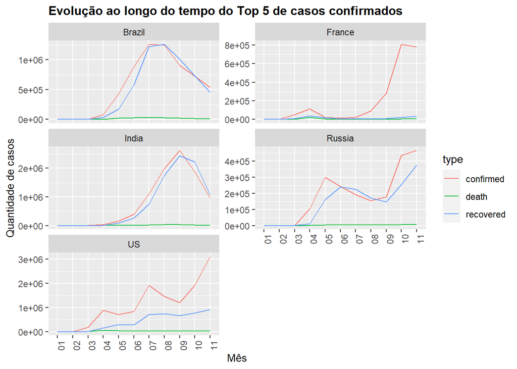

```r
ggplot(Top_5) +
  geom_line(aes(x=mes, y=total_casos, group=type, colour=type)) +
  facet_wrap(~country, ncol=2, scales="free_y") +
  theme(axis.text.x = element_text(angle = 90))+
  scale_y_continuous(n.breaks = 5)+
  labs(x = "Mês", y = "Quantidade de casos") +
  theme(axis.title = element_text(size=10), plot.title = element_text(size=12, face="bold")) +
  ggtitle("Evolução ao longo do tempo do Top 5 de casos confirmados")
```

### **5- Proporção entre quantidade de óbitos e casos confirmados nos 5 paises com mais casos confirmados**

- Isso seria útil para sabermos os locais em que o vírus mais está matando as pessoas infectadas,
- Vale notar que pode haver distorções, como por exemplo, países ricos que testam mais e em consequência tem mais casos confirmados. Ao fazer a divisão de mortes por confirmados, como o país testa mais, o denominador fica maior, e em consequência o resultado da divisão menor, fazendo parecer que o vírus é menos mortal nesses países do que em países que testam mais. Países mais pobres tendem a apresentar subnotificações e só testar pessoas em casos críticos, assim, o resultado da divisão tende a ser maior do que em países ricos.
- Pivotando o dataframe

```r
#install.packages('reshape')
library(reshape)
# Primeiro iremos pivotar o Data Frame
#total_3situacoes_5
total_classe <- cast(total_3situacoes_5, country ~ type, value = 'total_casos' )
total_classe
```

```
##   country confirmed  death recovered
## 1  Brazil   6071401 169183   5457973
## 2  France   2191180  48807    157259
## 3   India   9139865 133738   8562641
## 4  Russia   2071858  35838   1582768
## 5      US  12246849 256782   4526513
```

#### **Total de casos notificados x Óbitos**

- Gerando o gráfico

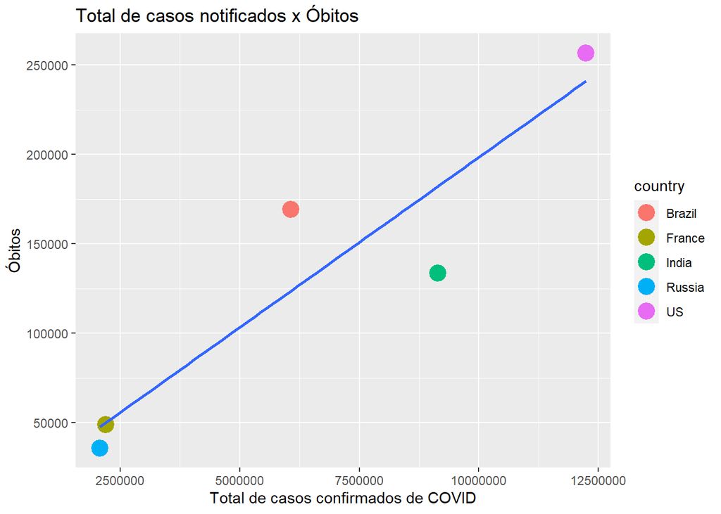

```r
g8 <- ggplot(total_classe) +
  geom_point(aes(x = confirmed, y = death ,color = country),stroke=1.5, size=4) +
   geom_smooth(aes(x = confirmed, y = death), se = FALSE, formula = y ~ x,method = "lm", fullrange=TRUE)+
  labs(title = 'Total de casos notificados x Óbitos',
  y = 'Óbitos',
  x = 'Total de casos confirmados de COVID')

g8
```

- A linha azul traça uma relação do tipo y ~ x entre os casos confirmados de COVID e o total de óbitos
- SObre o que foi abordado sobre a testagem, por exemplo, se o Brasil fizesse mais testes na população sem investir na recuperação e melhora dos pacientes, seu ponto se deslocaria na horizontal para a direita, dando a impressão de que o vírus é menos letal.
- Índice de mortes em relação aos casos confirmados (morte/confirmado), onde 1 representaria uma doença com 100% de letalidade

```r
total_classe <- mutate(total_classe, proporcao_obitos = death/confirmed) %>%
  arrange(-proporcao_obitos)
total_classe
```

```
##   country confirmed  death recovered proporcao_obitos
## 1  Brazil   6071401 169183   5457973       0.02786556
## 2  France   2191180  48807    157259       0.02227430
## 3      US  12246849 256782   4526513       0.02096719
## 4  Russia   2071858  35838   1582768       0.01729752
## 5   India   9139865 133738   8562641       0.01463238
```

#### **A proporção de mortes em relação aos casos confirmados de COVID**

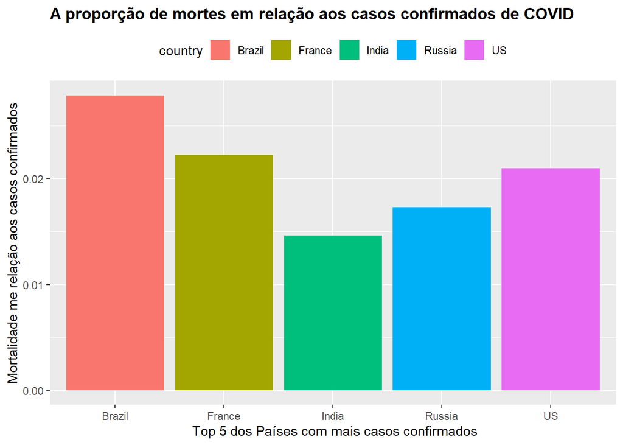

```r
g1 <- ggplot(total_classe, aes(y = proporcao_obitos, x = country, fill= country) ) +
  geom_bar(stat = "identity")+
  labs(title = expression (paste(bold('A proporção de mortes em relação aos casos confirmados de COVID'))),
  y = 'Mortalidade me relação aos casos confirmados',
  x = ' Top 5 dos Países com mais casos confirmados')+
  theme(legend.position = "top")

g1
```

### **6- Análise dos últimos 45 dias nos países Top 5 de casos confirmado**

- Até então estavamos acompanhando os casos totais, a presente parte da análise focará nos últimos 45 dias. Isso permitirá verificar mudanças de comportamento recentes na proliferação do vírus.
- Observe que apesar do dataset ter sido atualizado em 24 NOV 20, os últimos registros são de 22 NOV 20. Por isso, os 45 dias compreendem o período de **08 OUT a 22 NOV de 2020**

```r
Top_5_45_dias = coronavirus %>%
  filter(country %in% c('US','India','Brazil','France','Russia'))%>%
  filter(date>"2020-10-08")%>%
  group_by(type, country) %>%
  summarise(total_casos = sum(cases))%>%
  arrange(country)
#Top_5_45_dias
```

#### **Os últimos 45 dias - A proporção de recuperação, mortes e confirmações de COVID**

- Explorando em um gráfico de barras as 3 situações por país

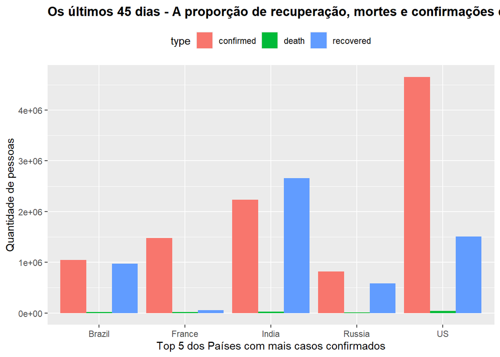

```r
g45 <- ggplot(Top_5_45_dias, aes(y = total_casos, x = country, fill = type)) +
  geom_bar(stat = "identity", position='dodge')+
  labs(title = expression (paste(bold('Os últimos 45 dias - A proporção de recuperação, mortes e confirmações de COVID'))),
  y = 'Quantidade de pessoas',
  x = 'Top 5 dos Países com mais casos confirmados')+
  theme(legend.position = "top")

g45
```

#### **Os últimos 45 dias - Total de casos de óbito por COVID**

- Observando apenas os casos de óbito dos últimos 45 dias em um gráfico de barras do top 5 de casos confirmados.

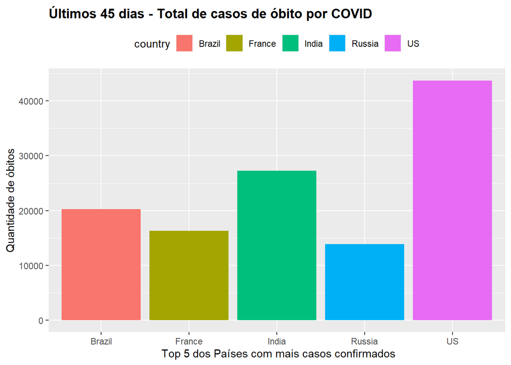

```r
Top_5_45_dias_obito<-  filter(Top_5_45_dias, type == "death")


g45_2 <- ggplot(Top_5_45_dias_obito, aes(y = total_casos, x = country, fill=country )) +
  geom_bar(stat = "identity", position='dodge')+
  labs(title = expression (paste(bold('Últimos 45 dias - Total de casos de óbito por COVID'))),
  y = 'Quantidade de óbitos',
  x = ' Top 5 dos Países com mais casos confirmados')+
  theme(legend.position = "top")

g45_2
```

#### Evolução ao longo dos últimos 45 dias do Top 5 de casos confirmados

- Gerando o dataframe:

```r
Top_5_45_dias_data = coronavirus %>%
  filter(country %in% c('US','India','Brazil','France','Russia'))%>%
  filter(date>"2020-10-08")%>%
  group_by(type, country, date) %>%
  summarise(total_casos = sum(cases))%>%
  arrange(country)
#Top_5_45_dias_data
```

#### **Evolução ao longo dos últimos 45 dias do Top 5 de casos confirmados**

-Plotando o gráfico:

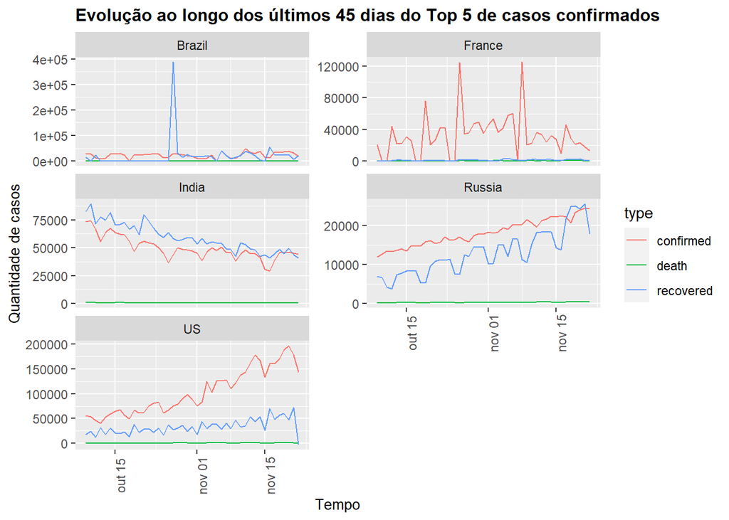

```r
ggplot(Top_5_45_dias_data) +
  geom_line(aes(x=date, y=total_casos, group=type, colour=type)) +
  facet_wrap(~country, ncol=2, scales="free_y") +
  theme(axis.text.x = element_text(angle = 90))+
  scale_y_continuous(n.breaks = 5)+
  labs(x = "Tempo", y = "Quantidade de casos") +
  theme(axis.title = element_text(size=10), plot.title = element_text(size=12, face="bold")) +
  ggtitle("Evolução ao longo dos últimos 45 dias do Top 5 de casos confirmados")
```

- Pivotando o dataframe

```r
#install.packages('reshape')
library(reshape)

# Primeiro iremos pivotar o Data Frame
#total_3situacoes_5
total_classe_45 <- cast(Top_5_45_dias, country ~ type, value = 'total_casos' )
total_classe_45
```

```
##   country confirmed death recovered
## 1  Brazil   1042957 20226    969881
## 2  France   1479476 16268     54717
## 3   India   2233714 27248   2656572
## 4  Russia    818255 13899    584571
## 5      US   4652395 43718   1505261
```

#### **Os últimos 45 dias - Total de casos notificados x Óbitos**

- Gerando o gráfico

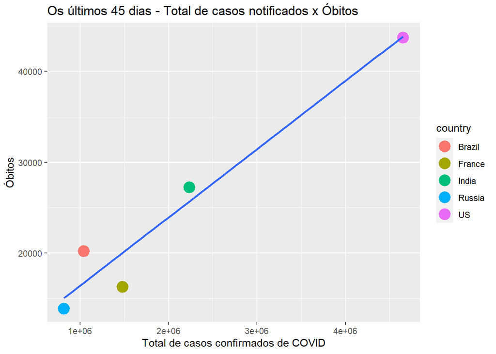

```r
g8 <- ggplot(total_classe_45) +
  geom_point(aes(x = confirmed, y = death ,color = country),stroke=1.5, size=4) +
   geom_smooth(aes(x = confirmed, y = death), se = FALSE, formula = y ~ x,method = "lm", fullrange=TRUE)+
  labs(title = 'Os últimos 45 dias - Total de casos notificados x Óbitos',
  y = 'Óbitos',
  x = 'Total de casos confirmados de COVID')

g8
```

### **7- A 2ª Onda de infecções**

- Agrupando o conjunto de dados pelo tempo

```r
total_mundo_tempo <- coronavirus %>%
  group_by(date,type) %>%
  summarise(total_casos = sum(cases))%>%
  arrange(date)
#total_mundo_tempo
```

#### **Evolução ao longo do tempo dos casos de COVID pelo mundo**

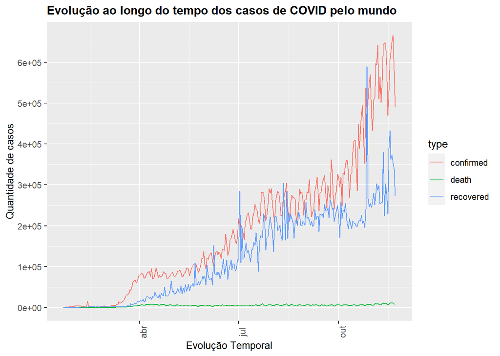

```r
ggplot(total_mundo_tempo) +
  geom_line(aes(x=date, y=total_casos, group=type, colour=type)) +
  theme(axis.text.x = element_text(angle = 90))+
  scale_y_continuous(n.breaks = 10)+
  labs(x = "Evolução Temporal", y = "Quantidade de casos") +
  theme(axis.title = element_text(size=10), plot.title = element_text(size=12, face="bold")) +
  ggtitle("Evolução ao longo do tempo dos casos de COVID pelo mundo")
```

- A análise pode ser feita com base nos casos mensais e não diários:

```r
total_mundo_mensal <- coronavirus %>%
  mutate(mes = format(date, '%m')) %>%
  group_by(mes,type) %>%
  summarise(total_casos = sum(cases))%>%
  arrange(mes)
#total_mundo_mensal
```

#### **Evolução mensal dos casos de COVID pelo mundo**

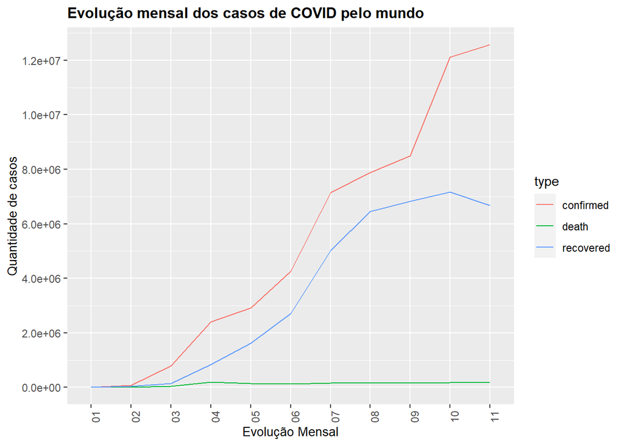

```r
ggplot(total_mundo_mensal) +
  geom_line(aes(x=mes, y=total_casos, group=type, colour=type)) +
  theme(axis.text.x = element_text(angle = 90))+
  scale_y_continuous(n.breaks = 10)+
  labs(x = "Evolução Mensal", y = "Quantidade de casos") +
  theme(axis.title = element_text(size=10), plot.title = element_text(size=12, face="bold")) +
  ggtitle("Evolução mensal dos casos de COVID pelo mundo")
```

- Observando apenas a evolução das mortes ao longo do tempo

```r
total_mundo_tempo_mortes <- filter(total_mundo_tempo,type=='death' )

#total_mundo_tempo_mortes
```

#### **Evolução temporal dos casos de óbito por COVID**

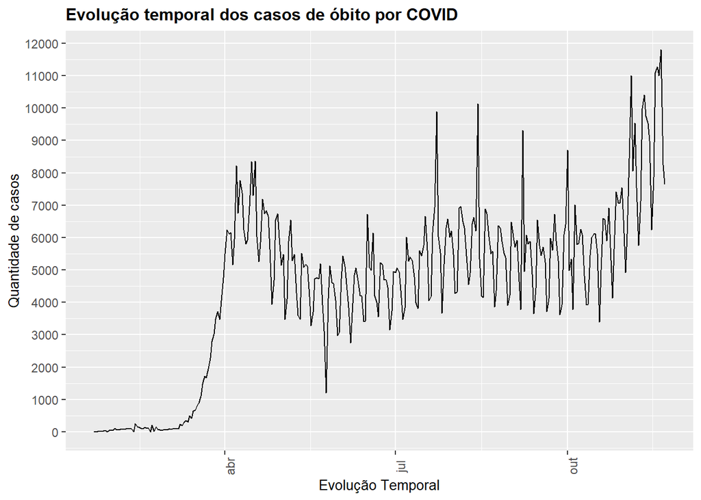

```r
ggplot(total_mundo_tempo_mortes) +
  geom_line(aes(x=date, y=total_casos)) +
  theme(axis.text.x = element_text(angle = 90))+
  scale_y_continuous(n.breaks = 10)+
  labs(x = "Evolução Temporal", y = "Quantidade de casos") +
  theme(axis.title = element_text(size=10), plot.title = element_text(size=12, face="bold")) +
  ggtitle("Evolução temporal dos casos de óbito por COVID")
```

- Analisando as mortes mensais Gerando o dataframe

```r
total_mundo_mortes_mensal <- filter(total_mundo_mensal,type=='death')
#total_mundo_mortes_mensal
```

#### **Evolução mensal dos casos de óbito por COVID ao redor do mundo**

Plotando o gráfico:

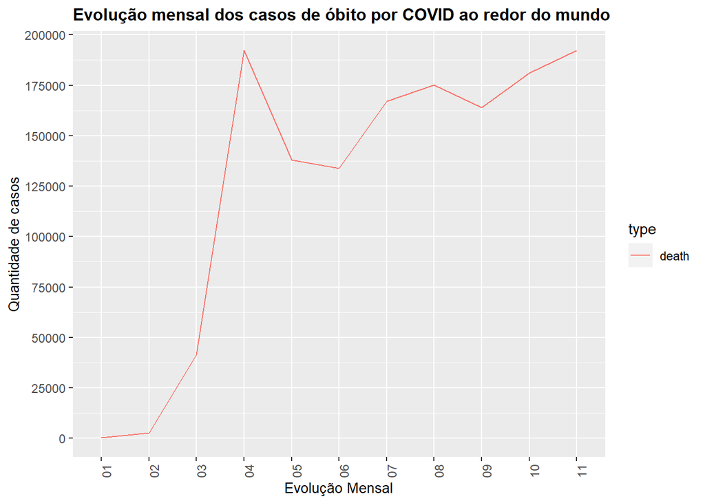

```r
ggplot(total_mundo_mortes_mensal) +
  geom_line(aes(x=mes, y=total_casos, group=type, colour=type)) +
  theme(axis.text.x = element_text(angle = 90))+
  scale_y_continuous(n.breaks = 10)+
  labs(x = "Evolução Mensal", y = "Quantidade de casos") +
  theme(axis.title = element_text(size=10), plot.title = element_text(size=12, face="bold")) +
  ggtitle("Evolução mensal dos casos de óbito por COVID ao redor do mundo")
```

- Nota-se que em **ABRIL** a doença atingiu um número elevado de mortes, que diminuiu em **JUNHO**, voltando a crescer até **AGOSTO**, reduzindo em **SETEMBRO**, e mantendo uma tendência de crescimento desde então. Nota-se que os valores de óbito atuais, são próximos ao pico de **ABRIL**.